# Exploratory Data Analysis -EDA

## Visualize the behavior of the binary outcome with respect to the Categorical inputs

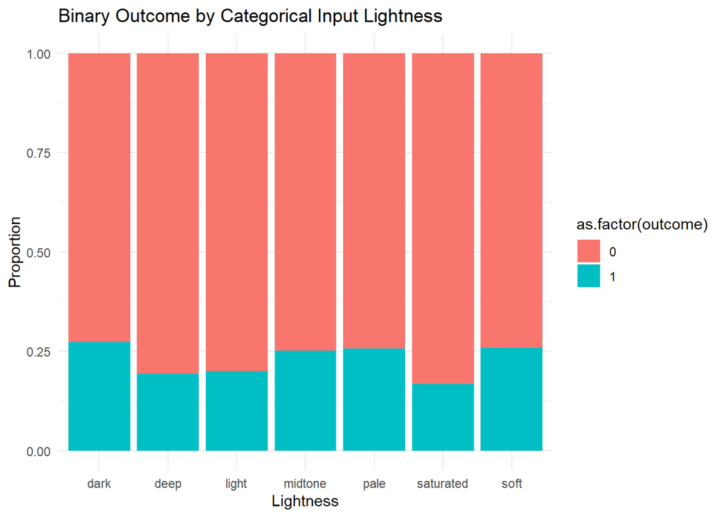

```r
ggplot(df_train, aes(x = Lightness, fill = as.factor(outcome))) +
  geom_bar(position = "fill") +
  labs(title = "Binary Outcome by Categorical Input Lightness", x = "Lightness", y = "Proportion") +
  theme_minimal()
```

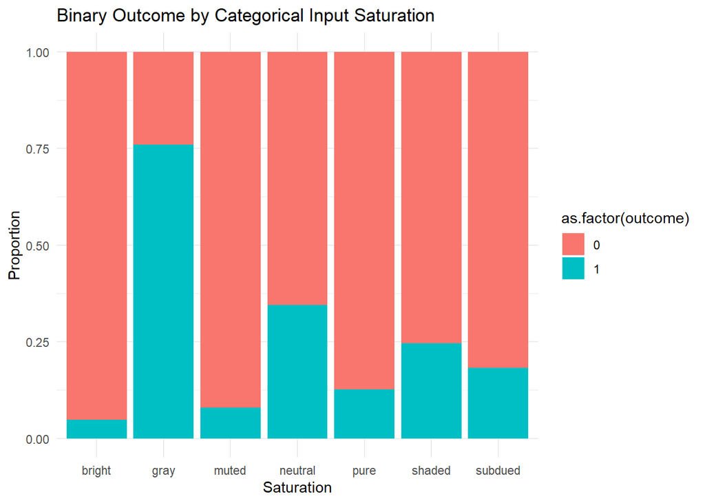

```r
ggplot(df_train, aes(x = Saturation, fill = as.factor(outcome))) +
  geom_bar(position = "fill") +
  labs(title = "Binary Outcome by Categorical Input Saturation", x = "Saturation", y = "Proportion") +
  theme_minimal()
```

## Visualize the behavior of the binary outcome with respect to the Continuous inputs

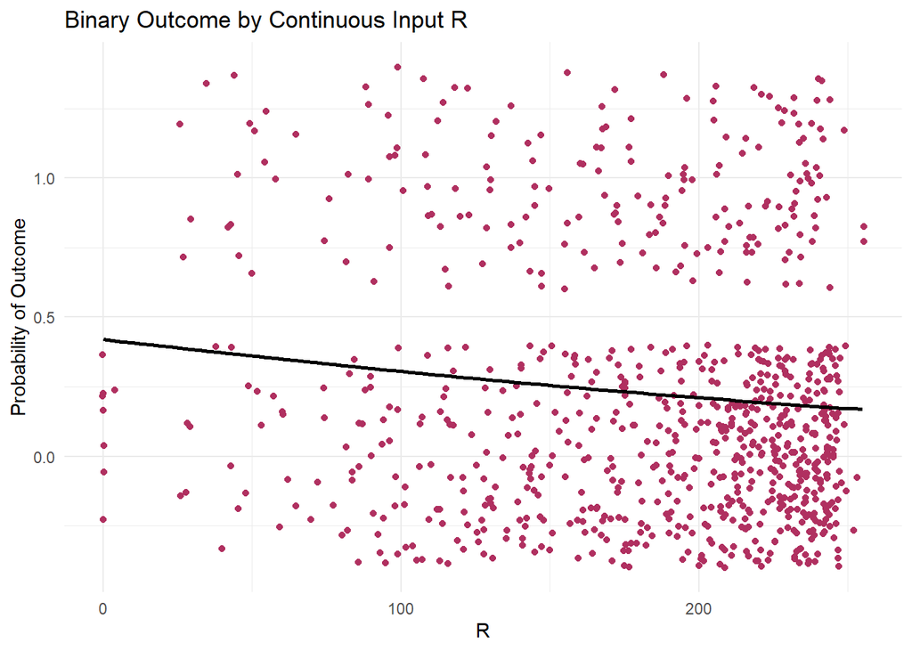

```r
ggplot(df_train, aes(x = R, y = outcome)) +
  geom_jitter(color="maroon") +
  geom_smooth(method = "glm", formula = y ~ x,method.args = list(family = "binomial"), se = FALSE,color="black") +
  labs(title = "Binary Outcome by Continuous Input R", x = "R", y = "Probability of Outcome") +
  theme_minimal()
```

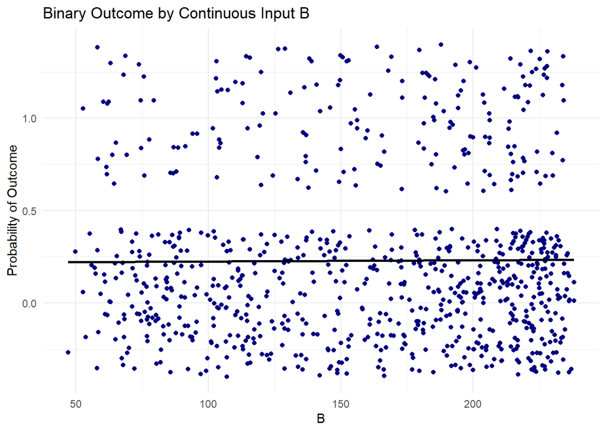

```r
ggplot(df_train, aes(x = B, y = outcome)) +
  geom_jitter(color="navy") +
  geom_smooth(method = "glm", formula = y ~ x,method.args = list(family = "binomial"), se = FALSE,color="black") +
  labs(title = "Binary Outcome by Continuous Input B", x = "B", y = "Probability of Outcome") +
  theme_minimal()
```

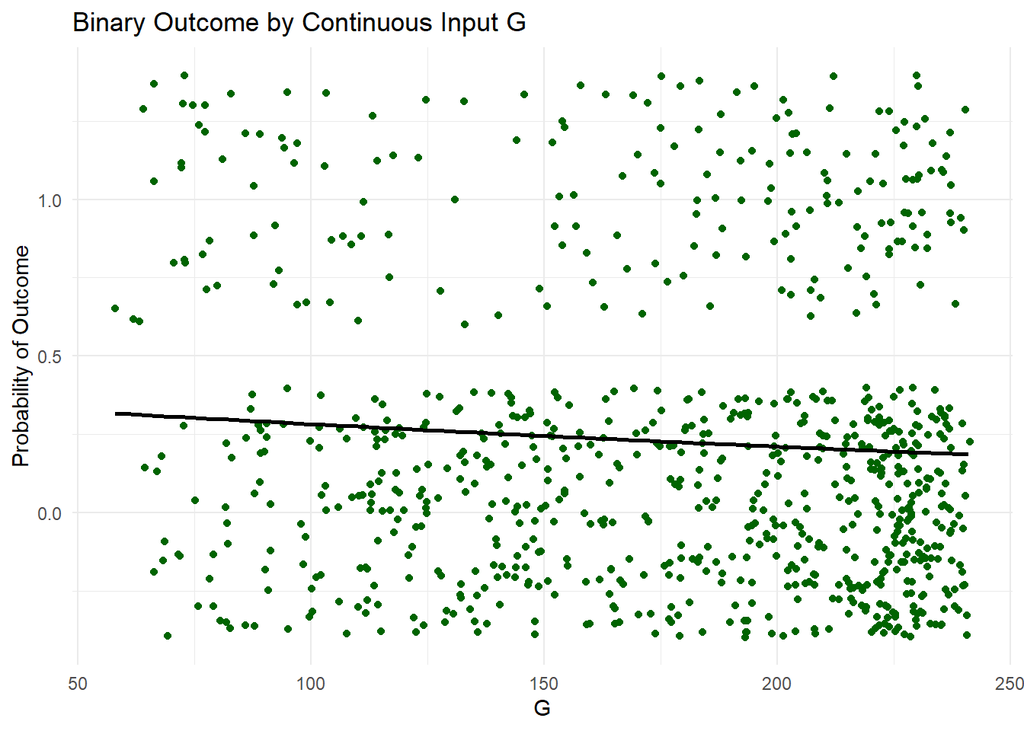

```r
ggplot(df_train, aes(x = G, y = outcome)) +
  geom_jitter(color="darkgreen") +
  geom_smooth(method = "glm", formula = y ~ x,method.args = list(family = "binomial"), se = FALSE,color="black") +
  labs(title = "Binary Outcome by Continuous Input G", x = "G", y = "Probability of Outcome") +
  theme_minimal()
```

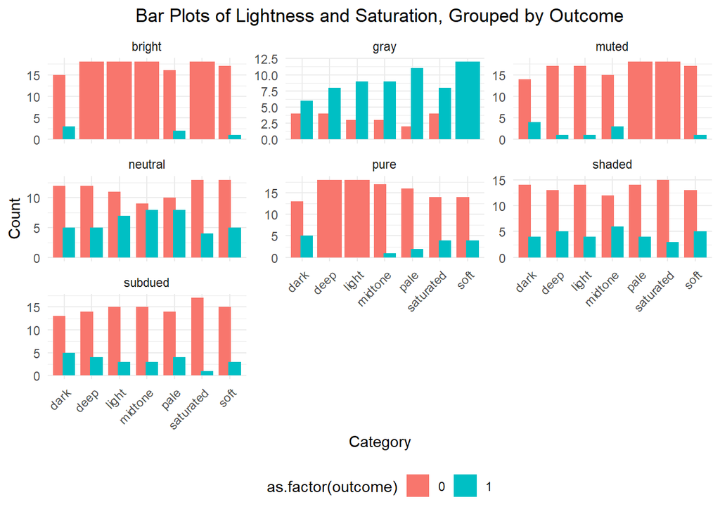

```r
library(ggplot2)

ggplot(df_train, aes(x = Lightness, fill = as.factor(outcome))) +
  geom_bar(position = position_dodge(width = 0.7)) +
  labs(title = "Bar Plots of Lightness and Saturation, Grouped by Outcome",
       x = "Category", y = "Count") +
  facet_wrap(~Saturation, scales = "free_y") +
  theme_minimal() +
  theme(axis.text.x = element_text(angle = 45, vjust = 1, hjust=1),
        plot.title = element_text(hjust = 0.5),
        legend.position = "bottom")
```

A thorough exploration of the dataset has been completed. Categorical variables were analyzed using counts to understand their distribution. For continuous variables, histograms or density plots were created to visualize their shapes and assess if they resembled a normal (Gaussian) distribution. Additionally, continuous variables were grouped based on both categorical variables and the binary outcome variable. This allowed for comparisons of distributions and summary statistics (like mean and median) across different groups. The relationships between continuous input variables were explored through correlation analysis. Visualizations were also created to depict the relationships between continuous outputs (response and logit-transformed response) with respect to the continuous inputs. These visualizations helped identify trends and potential dependencies on categorical inputs. Finally, methods for visualizing the behavior of the binary outcome variable with respect to both continuous and categorical inputs were explored. This comprehensive exploration provides a deeper understanding of the data, including potential patterns, relationships between variables, and potential biases. This knowledge can be used for further analysis, such as model building or hypothesis testing.